# IRYSY_notebook

#### ANALIZA danych dotyczących Irysów

Zbiór danych zawiera informacje o trzech gatunkach irysów: Iris setosa, Iris versicolor, i Iris virginica.

Dane obejmują pomiary czterech cech: długość i szerokość działki kielicha oraz długość i szerokość płatka.

Każdy wiersz w zbiorze danych reprezentuje pojedynczy kwiat, a wartości pomiarów są podane w centymetrach.

Zbiór składa się z 150 próbek, po 50 dla każdego gatunku, i jest szeroko stosowany jako podstawowy zbiór danych do testowania algorytmów klasyfikacji oraz w nauce o danych i uczeniu maszynowym.

Kolumny:

- **długość kielicha (sepal length)** - Długość kielicha w cm
- **szerokość kielicha (sepal width)** - Szerokość kielicha w cm
- **długość płatka (petal length)** - Długość płatka w cm
- **szerokość płatka (petal width)** - Szerokość płatka w cm
- **klasa (class)** - Klasa irysa (setosa, versicolor, virginica)

|  | długość kielicha (sepal length) | szerokość kielicha (sepal width) | długość płatka (petal length) | szerokość płatka (petal width) | klasa (class) |
| --- | --- | --- | --- | --- | --- |
| 0 | 5.1 | 3.5 | 1.4 | 0.2 | Iris-setosa |
| 1 | 4.9 | 3.0 | 1.4 | 0.2 | Iris-setosa |
| 2 | 4.7 | 3.2 | 1.3 | 0.2 | Iris-setosa |
| 3 | 4.6 | 3.1 | 1.5 | 0.2 | Iris-setosa |
| 4 | 5.0 | 3.6 | 1.4 | 0.2 | Iris-setosa |
| ... | ... | ... | ... | ... | ... |
| 145 | 6.7 | 3.0 | 5.2 | 2.3 | Iris-virginica |
| 146 | 6.3 | 2.5 | 5.0 | 1.9 | Iris-virginica |
| 147 | 6.5 | 3.0 | 5.2 | 2.0 | Iris-virginica |
| 148 | 6.2 | 3.4 | 5.4 | 2.3 | Iris-virginica |
| 149 | 5.9 | 3.0 | 5.1 | 1.8 | Iris-virginica |

150 rows × 5 columns

## 1. KROK 1

### 1.1 Zrozumienie danych, czyli ogólny przegląd danych

```
<class 'pandas.core.frame.DataFrame'>
RangeIndex: 150 entries, 0 to 149
Data columns (total 5 columns):
 #   Column                            Non-Null Count  Dtype
---  ------                            --------------  -----
 0   długość kielicha (sepal length)   150 non-null    float64
 1   szerokość kielicha (sepal width)  150 non-null    float64
 2   długość płatka (petal length)     150 non-null    float64
 3   szerokość płatka (petal width)    150 non-null    float64
 4   klasa (class)                     150 non-null    object
dtypes: float64(4), object(1)
memory usage: 6.0+ KB
```

```
klasa (class)
Iris-setosa        50
Iris-versicolor    50
Iris-virginica     50
Name: count, dtype: int64
```

##### Dowiedzieliśmy się,że mamy 150 wierszy i 5 kolumn z 3 gatunkami Irysów: Iris setosa, Iris versicolor, i Iris virginica.

##### Każdy gatunek kwiata ma po 50 próbek.

##### Możemy sprawdzić czy poszczególne gatunki Irysów różnią się długoscią i szerokościa kielicha oraz długością i szerokością płatka.

|  | długość kielicha (sepal length) | szerokość kielicha (sepal width) | długość płatka (petal length) | szerokość płatka (petal width) | klasa (class) |
| --- | --- | --- | --- | --- | --- |
| 33 | 5.5 | 4.2 | 1.4 | 0.2 | Iris-setosa |
| 103 | 6.3 | 2.9 | 5.6 | 1.8 | Iris-virginica |
| 63 | 6.1 | 2.9 | 4.7 | 1.4 | Iris-versicolor |
| 79 | 5.7 | 2.6 | 3.5 | 1.0 | Iris-versicolor |
| 42 | 4.4 | 3.2 | 1.3 | 0.2 | Iris-setosa |
| 0 | 5.1 | 3.5 | 1.4 | 0.2 | Iris-setosa |
| 45 | 4.8 | 3.0 | 1.4 | 0.3 | Iris-setosa |
| 136 | 6.3 | 3.4 | 5.6 | 2.4 | Iris-virginica |
| 30 | 4.8 | 3.1 | 1.6 | 0.2 | Iris-setosa |
| 144 | 6.7 | 3.3 | 5.7 | 2.5 | Iris-virginica |

|  | długość kielicha (sepal length) | szerokość kielicha (sepal width) | długość płatka (petal length) | szerokość płatka (petal width) | klasa (class) |
| --- | --- | --- | --- | --- | --- |
| 129 | 7.2 | 3.0 | 5.8 | 1.6 | Iris-virginica |
| 45 | 4.8 | 3.0 | 1.4 | 0.3 | Iris-setosa |
| 143 | 6.8 | 3.2 | 5.9 | 2.3 | Iris-virginica |
| 47 | 4.6 | 3.2 | 1.4 | 0.2 | Iris-setosa |
| 60 | 5.0 | 2.0 | 3.5 | 1.0 | Iris-versicolor |
| 4 | 5.0 | 3.6 | 1.4 | 0.2 | Iris-setosa |
| 123 | 6.3 | 2.7 | 4.9 | 1.8 | Iris-virginica |
| 27 | 5.2 | 3.5 | 1.5 | 0.2 | Iris-setosa |
| 97 | 6.2 | 2.9 | 4.3 | 1.3 | Iris-versicolor |
| 89 | 5.5 | 2.5 | 4.0 | 1.3 | Iris-versicolor |

## Irys - versicolor

[figure not shown]

## Irys - setosa

[figure not shown]

### 1.2. Sprawdzam unikatowe wartości ogólnie dla całego zbioru

```
długość kielicha (sepal length)     35
szerokość kielicha (sepal width)    23
długość płatka (petal length)       43
szerokość płatka (petal width)      22
klasa (class)                        3
dtype: int64
```

### 1.2.1. Unikatowe wartości dla poszczególnych klas Irysa w zależności od długości i szerokości płatka i kielicha

|  | klasa (class) | długość kielicha (sepal length) | szerokość kielicha (sepal width) | długość płatka (petal length) | szerokość płatka (petal width) |
| --- | --- | --- | --- | --- | --- |
| 0 | Iris-setosa | 15 | 16 | 9 | 6 |
| 1 | Iris-versicolor | 21 | 14 | 19 | 9 |
| 2 | Iris-virginica | 21 | 13 | 20 | 12 |

### Wniosek: w każdej kolumnie mamy:

- 35 unikatowych różnych długości kielichów
- 23 unikatowe różne szerokości kielichów
- 43 unikatowe długości płatków
- 22 unikatowe szerokości płatków
- 3 gatunki Irysów

### Zagłębiając się konkretnie w poszczególne klasy Irysów mamy również unikatowe wartości

- najwięcej jest unikatów dla *Irysa versicolor* oraz *virginica* pod względem **długości kielicha** oraz **długości płatka**

|  | długość kielicha (sepal length) | szerokość kielicha (sepal width) | długość płatka (petal length) | szerokość płatka (petal width) |
| --- | --- | --- | --- | --- |
| count | 150.000000 | 150.000000 | 150.000000 | 150.000000 |
| mean | 5.843333 | 3.054000 | 3.758667 | 1.198667 |
| std | 0.828066 | 0.433594 | 1.764420 | 0.763161 |
| min | 4.300000 | 2.000000 | 1.000000 | 0.100000 |
| 25% | 5.100000 | 2.800000 | 1.600000 | 0.300000 |
| 50% | 5.800000 | 3.000000 | 4.350000 | 1.300000 |
| 75% | 6.400000 | 3.300000 | 5.100000 | 1.800000 |
| max | 7.900000 | 4.400000 | 6.900000 | 2.500000 |

|  | count | mean | std | min | 25% | 50% | 75% | max |
| --- | --- | --- | --- | --- | --- | --- | --- | --- |
| długość kielicha (sepal length) | 150.0 | 5.84 | 0.83 | 4.3 | 5.1 | 5.80 | 6.4 | 7.9 |
| szerokość kielicha (sepal width) | 150.0 | 3.05 | 0.43 | 2.0 | 2.8 | 3.00 | 3.3 | 4.4 |
| długość płatka (petal length) | 150.0 | 3.76 | 1.76 | 1.0 | 1.6 | 4.35 | 5.1 | 6.9 |
| szerokość płatka (petal width) | 150.0 | 1.20 | 0.76 | 0.1 | 0.3 | 1.30 | 1.8 | 2.5 |

### Podsumowanie KROKU 1 analizy:

|  | długość kielicha (sepal length) | szerokość kielicha (sepal width) | długość płatka (petal length) | szerokość płatka (petal width) | klasa (class) |
| --- | --- | --- | --- | --- | --- |
| 34 | 4.9 | 3.1 | 1.5 | 0.1 | Iris-setosa |
| 37 | 4.9 | 3.1 | 1.5 | 0.1 | Iris-setosa |
| 142 | 5.8 | 2.7 | 5.1 | 1.9 | Iris-virginica |

#### Zdublowany mamy wiersz 34, 37 i 142 gdzie:

- 2 duplikaty sa dla Irys-setosa
- 1 duplikat dla Irys-virginica

### Pozostało 147 wierszy w 5 kolumnach po usunięciu duplikatów.

|  | długość kielicha (sepal length) | szerokość kielicha (sepal width) | długość płatka (petal length) | szerokość płatka (petal width) | klasa (class) |
| --- | --- | --- | --- | --- | --- |
| 0 | 5.1 | 3.5 | 1.4 | 0.2 | Iris-setosa |
| 1 | 4.9 | 3.0 | 1.4 | 0.2 | Iris-setosa |
| 2 | 4.7 | 3.2 | 1.3 | 0.2 | Iris-setosa |
| 3 | 4.6 | 3.1 | 1.5 | 0.2 | Iris-setosa |
| 4 | 5.0 | 3.6 | 1.4 | 0.2 | Iris-setosa |
| ... | ... | ... | ... | ... | ... |
| 145 | 6.7 | 3.0 | 5.2 | 2.3 | Iris-virginica |
| 146 | 6.3 | 2.5 | 5.0 | 1.9 | Iris-virginica |
| 147 | 6.5 | 3.0 | 5.2 | 2.0 | Iris-virginica |
| 148 | 6.2 | 3.4 | 5.4 | 2.3 | Iris-virginica |
| 149 | 5.9 | 3.0 | 5.1 | 1.8 | Iris-virginica |

147 rows × 5 columns

### Grupowanie ponowne po klasie oraz dane statystyczne dla poszczególnej klasy

| klasa (class) | długość kielicha (sepal length) mean | długość kielicha (sepal length) median | długość kielicha (sepal length) std | długość kielicha (sepal length) min | długość kielicha (sepal length) max | szerokość kielicha (sepal width) mean | szerokość kielicha (sepal width) median | szerokość kielicha (sepal width) std | szerokość kielicha (sepal width) min | szerokość kielicha (sepal width) max | długość płatka (petal length) mean | długość płatka (petal length) median | długość płatka (petal length) std | długość płatka (petal length) min | długość płatka (petal length) max | szerokość płatka (petal width) mean | szerokość płatka (petal width) median | szerokość płatka (petal width) std | szerokość płatka (petal width) min | szerokość płatka (petal width) max |
| --- | --- | --- | --- | --- | --- | --- | --- | --- | --- | --- | --- | --- | --- | --- | --- | --- | --- | --- | --- | --- |
| Iris-setosa | 5.01 | 5.0 | 0.35 | 4.3 | 5.8 | 3.42 | 3.4 | 0.38 | 2.3 | 4.4 | 1.46 | 1.50 | 0.17 | 1.0 | 1.9 | 0.24 | 0.2 | 0.11 | 0.1 | 0.6 |
| Iris-versicolor | 5.94 | 5.9 | 0.52 | 4.9 | 7.0 | 2.77 | 2.8 | 0.31 | 2.0 | 3.4 | 4.26 | 4.35 | 0.47 | 3.0 | 5.1 | 1.33 | 1.3 | 0.20 | 1.0 | 1.8 |
| Iris-virginica | 6.59 | 6.5 | 0.64 | 4.9 | 7.9 | 2.97 | 3.0 | 0.32 | 2.2 | 3.8 | 5.55 | 5.55 | 0.55 | 4.5 | 6.9 | 2.03 | 2.0 | 0.27 | 1.4 | 2.5 |

## 2. KROK 2

### 2.1. Brakujące dane

|  | długość kielicha (sepal length) | szerokość kielicha (sepal width) | długość płatka (petal length) | szerokość płatka (petal width) | klasa (class) |
| --- | --- | --- | --- | --- | --- |
| 0 | False | False | False | False | False |
| 1 | False | False | False | False | False |
| 2 | False | False | False | False | False |
| 3 | False | False | False | False | False |
| 4 | False | False | False | False | False |
| ... | ... | ... | ... | ... | ... |
| 145 | False | False | False | False | False |
| 146 | False | False | False | False | False |
| 147 | False | False | False | False | False |
| 148 | False | False | False | False | False |
| 149 | False | False | False | False | False |

150 rows × 5 columns

#### Uzyskano *False* czyli nie brakuje żadnych danych, ale sprawdzono jeszcze dodtakowo wartości brakujące w każdej kolumnie.

```
długość kielicha (sepal length)     0
szerokość kielicha (sepal width)    0
długość płatka (petal length)       0
szerokość płatka (petal width)      0
klasa (class)                       0
dtype: int64
```

#### Analiza wykazała, że *w żadnej kolumnie* nie brakuje danych.

## 3. KROK 3

### 3.1. Eksploracja poszczególych kolumn, analiza pojedynczych zmiennych

[output not shown]

### Po usunięciu duplikatów pozostaje 147 wierszy w 5 kolumnach

```
<class 'pandas.core.frame.DataFrame'>
Index: 147 entries, 0 to 149
Data columns (total 5 columns):
 #   Column                            Non-Null Count  Dtype
---  ------                            --------------  -----
 0   długość kielicha (sepal length)   147 non-null    float64
 1   szerokość kielicha (sepal width)  147 non-null    float64
 2   długość płatka (petal length)     147 non-null    float64
 3   szerokość płatka (petal width)    147 non-null    float64
 4   klasa (class)                     147 non-null    object
dtypes: float64(4), object(1)
memory usage: 6.9+ KB
```

### 3.2. Histogram pokazuje częstotliwość występowania kwiata w zależności od długości i szerokości płatków oraz kielichów

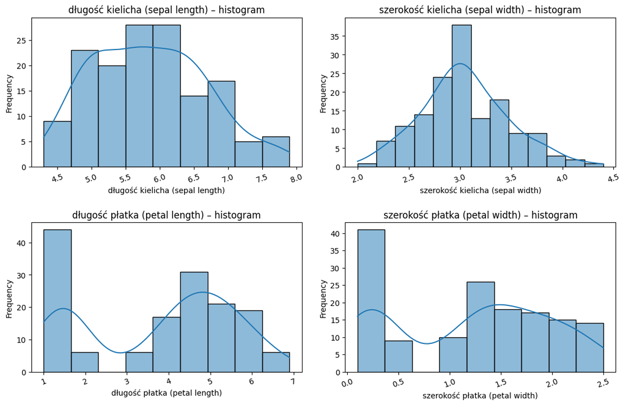

#### Histogram potwierdza, że *Irysy*:

1. długości płatków mają największą różnicę w cm
2. długości kielichów w większości nie odbiegają od siebie
3. najczęściej występująca szerokość kielicha ma 3 cm
4. najwięcej płatków tych kwiatów ma szerokość ok. 0,25 cm

### 3.3. Porównanie cech kwiatów Irysa

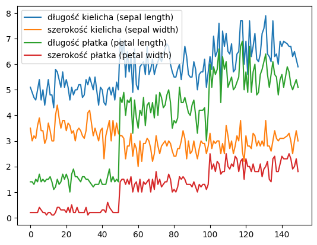

### 3.4. Wizualizacja *mediany* wartości środkowej dla każdej klasy IRYSA

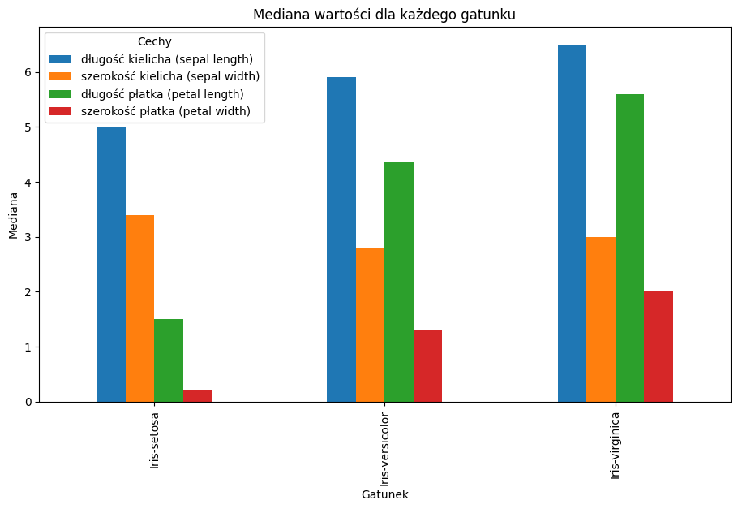

### Wnioski:

- długość kielicha jest największa dla gatunku **Irys - virginica**
- szerokość kielicha największą mają **Irysy-setosa**
- długość płatków największą mają **Irysy-virginica**
- szerokość płatka największa występuje u **Irysów-virginica**

### Pod względem wielkości płatka i kielicha góruje ***Irys virginica***

## 4. KROK 4

### 4.1. Transformacja danych/Naprawa błędów

#### Ponieważ nie ma kolumn gdzie brakuje danych (NaN) więc nie trzeba naprawiać błędów.

#### Jesli chodzi o zdublowane wartości/dane usunęliśmy już w *KROKU 3*, aby lepiej wyszły histogramy.

## 5. KROK 5

### 5.1. Analiza między zmiennymi/ Relacje między kolumnami

|  | długość kielicha (sepal length) | szerokość kielicha (sepal width) | długość płatka (petal length) | szerokość płatka (petal width) |
| --- | --- | --- | --- | --- |
| długość kielicha (sepal length) | 1.00 | -0.74 | 0.99 | 1.00 |
| szerokość kielicha (sepal width) | -0.74 | 1.00 | -0.80 | -0.75 |
| długość płatka (petal length) | 0.99 | -0.80 | 1.00 | 1.00 |
| szerokość płatka (petal width) | 1.00 | -0.75 | 1.00 | 1.00 |

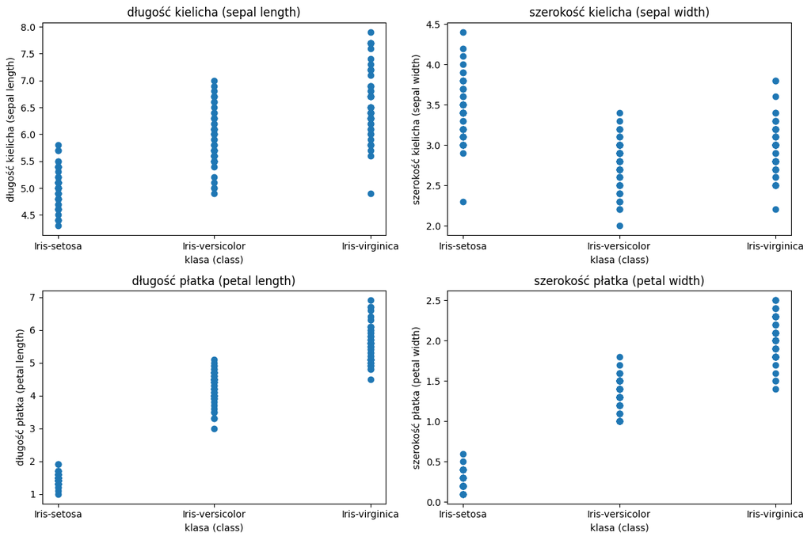

#### WNIOSKI: potwierdzają się poprzednie spostrzeżenia, czyli:

- najdłuższe kielichy ma odmiana *Irysa-virginica*, a najkrótsze kielichy ma odmiana *Irysa-setosa*
- najszersze kielichy ma gatunek *Irysa- setosa*, natomiast ma najmniejszą długość i szerokość płatka
- najdłuższe płatki ma odmiana *Irysa-virginica*, a najkrótsze *Irys - setosa*
- najszersze płatki ma również gatunek *Irysa-virginica*, a najmniejsze *Irys-setosa*

#### Ważną obserwacją jest również fakt, że **Irys-versicolor** ma *części wspólne* jeśli chodzi o długość i szerokość kielichów!

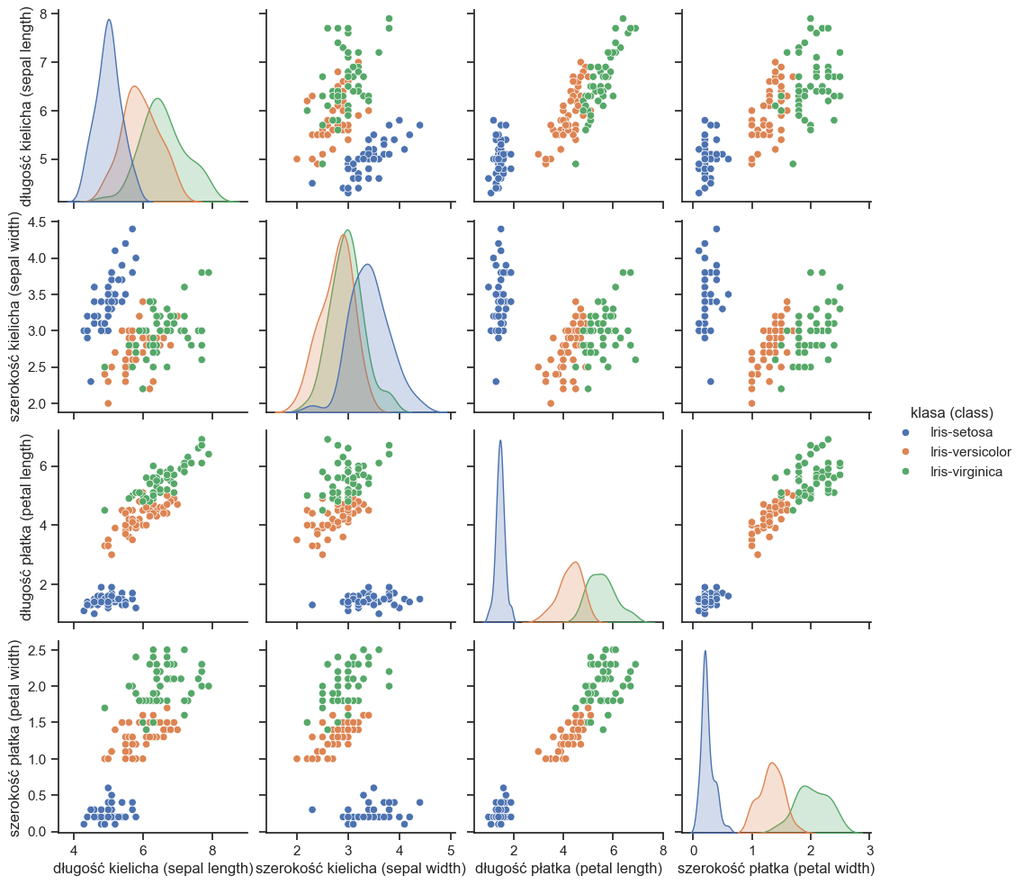

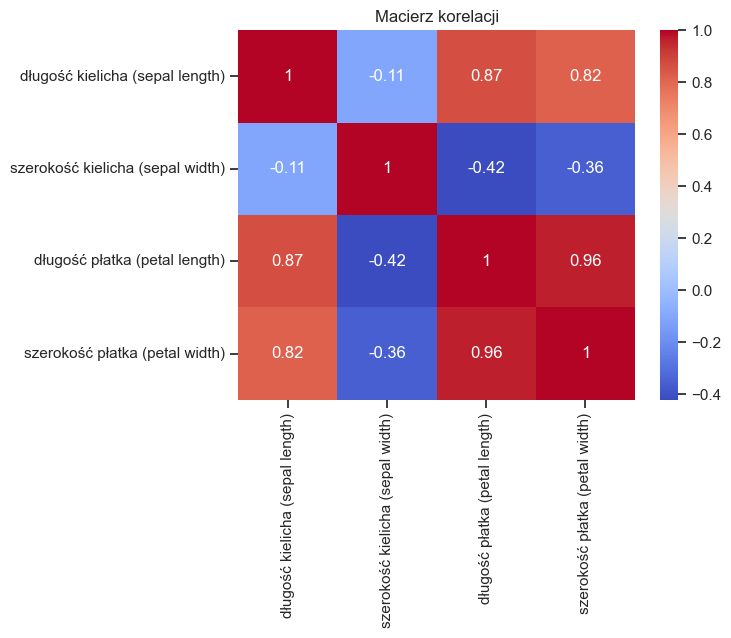

### Potwierdzamy silną korelację m.in. pomiędzy:

1. długością, a szerokością płatka (0,96) - co raczej nie dziwi, ponieważ kwiat wygląda ładniej
2. długością płatka, a długością kielicha (0,87) - ciekawa zależność
3. szerokością płatka, a długością kielicha (0,82) - bardzo ciekawe spostrzeżenie, że szerokość płatka zależy od długości kielicha (i odwrotnie)

## 6. KROK 6

### 6.1. Analiza wartości odstających tzw. outliers

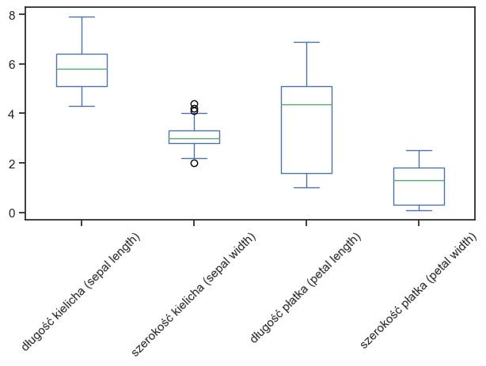

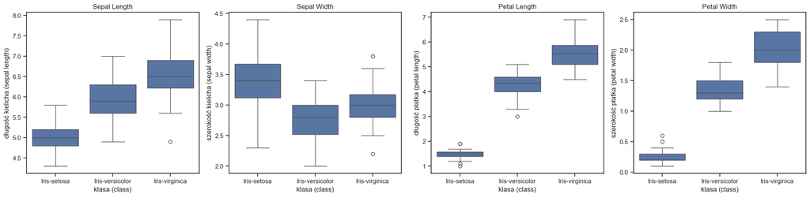

##### WNIOSKI dla wartości odstających:

Ogólny wykres pudełkowy nie wnosi wiele poza największymi odchyleniami w szerokościach kielichów , Natomiast wykres pudełkowy dla każdej funkcji osobny pokazuje ciekawe fakty:

1. jeśli chodzi o długość kielicha to najwięcej odchyleń (ale nie dużo) ma odmiana Irysa-virginica,
2. patrząc na szerokośc kielicha również obserwujemy odchylenia w odmianie Irysa-virginica
3. przyglądając się długości płatka to najwięcej odchyleń mamy w gatunku Irysa-setosa i trochę w Irysie-versicolor,
4. gatunek Irysa -setosa notuje również największe odchylenia jeśli chodzi o szerokość płatka

### WNIOSKI KOŃCOWE

[output not shown]